# Homework1-3210104129

Zhang Zhixian

# Part 1

1.The Iowa data set `iowa.csv` is a toy example that summarises the yield of wheat (bushels per acre) for the state of Iowa between 1930-1962. In addition to yield, year, rainfall and temperature were recorded as the main predictors of yield.

1. First, we need to load the data set into R using the command `read.csv()`. Use the help function to learn what arguments this function takes. Once you have the necessary input, load the data set into R and make it a data frame called `iowa.df`.

```r
iowa.df <- read.csv("D:/zhizhixian/Statistics-Computing-with-R/Data/Iowa.csv",header=T,sep=';')
iowa.df
```

```
##    Year Rain0 Temp1 Rain1 Temp2 Rain2 Temp3 Rain3 Temp4 Yield
## 1  1930 17.75  60.2  5.83  69.0  1.49  77.9  2.42  74.4  34.0
## 2  1931 14.76  57.5  3.83  75.0  2.72  77.2  3.30  72.6  32.9
## 3  1932 27.99  62.3  5.17  72.0  3.12  75.8  7.10  72.2  43.0
## 4  1933 16.76  60.5  1.64  77.8  3.45  76.4  3.01  70.5  40.0
## 5  1934 11.36  69.5  3.49  77.2  3.85  79.7  2.84  73.4  23.0
## 6  1935 22.71  55.0  7.00  65.9  3.35  79.4  2.42  73.6  38.4
## 7  1936 17.91  66.2  2.85  70.1  0.51  83.4  3.48  79.2  20.0
## 8  1937 23.31  61.8  3.80  69.0  2.63  75.9  3.99  77.8  44.6
## 9  1938 18.53  59.5  4.67  69.2  4.24  76.5  3.82  75.7  46.3
## 10 1939 18.56  66.4  5.32  71.4  3.15  76.2  4.72  70.7  52.2
## 11 1940 12.45  58.4  3.56  71.3  4.57  76.7  6.44  70.7  52.3
## 12 1941 16.05  66.0  6.20  70.0  2.24  75.1  1.94  75.1  51.0
## 13 1942 27.10  59.3  5.93  69.7  4.89  74.3  3.17  72.2  59.9
## 14 1943 19.05  57.5  6.16  71.6  4.56  75.4  5.07  74.0  54.7
```

[output cut: 19 more lines]

2. How many rows and columns does `iowa.df` have?

```r
dim(iowa.df)
```

```
## [1] 33 10
```

We have 33 rows and 10 columns.

3. What are the names of the columns of `iowa.df`?

```r
colnames(iowa.df)
```

```
##  [1] "Year"  "Rain0" "Temp1" "Rain1" "Temp2" "Rain2" "Temp3" "Rain3" "Temp4"
## [10] "Yield"
```

4. What is the value of row 5, column 7 of `iowa.df`?

```r
iowa.df[5,7]
```

```
## [1] 79.7
```

5. Display the second row of `iowa.df` in its entirety.

```r
iowa.df[2,]
```

```
##   Year Rain0 Temp1 Rain1 Temp2 Rain2 Temp3 Rain3 Temp4 Yield
## 2 1931 14.76  57.5  3.83    75  2.72  77.2   3.3  72.6  32.9
```

# Part 2

2.Syntax and class-typing.

1. For each of the following commands, either explain why they should be errors, or explain the non-erroneous result.

```
vector1 <- c("5", "12", "7", "32")
max(vector1)
sort(vector1)
sum(vector1)
```

Explain: For the fisrt commands, it can generate result: “7”, by comparing the first character of each character. For the second commands, it can generate result: “12” “32” “5” “7”, by comparing the first character of each character and reordering them in ascending order. For the third command, it is wrong, since the function ‘sum’ only can be used t sum up the numerical entries.

Correct version:

```r
vector1 <- c("5", "12", "7", "32")
sum(as.numeric(vector1))
```

```
## [1] 56
```

2. For the next series of commands, either explain their results, or why they should produce errors

```
vector2 <- c("5",7,12)
vector2[2] + vector2[3]
```

Explain: For the first command, it will produce error since both the vector2[2] and vector2[3] is character, because the output type of c{} function is determined from the highest type of the components in the hierarchy NULL < raw < logical < integer < double < complex < character < list < expression.

Correct version:

```r
vector2 <- as.numeric(c("5",7,12))
vector2[2] + vector2[3]
```

```
## [1] 19
```

```
dataframe3 <- data.frame(z1="5",z2=7,z3=12)
dataframe3[1,2] + dataframe3[1,3]
```

Explain: For the second command, it will produce the result 19. This is because dataframe3[1,2] equals numeric 7, dataframe3[1,3] equals numeric 12, so the result is 7+12=19.

```
list4 <- list(z1="6", z2=42, z3="49", z4=126)
list4[[2]]+list4[[4]]
list4[2]+list4[4]
```

Explain: For the third command, the first one will produce the result 168 cna the second one will produce error. This is because command [] and [[]] are different for the list. The former will still produce a list, which cannot be added up, and the later will show the corresponding content of the list, which can be added up.

# Part 3

3.Working with functions and operators.

1. The colon operator will create a sequence of integers in order. It is a special case of the function `seq()` which you saw earlier in this assignment. Using the help command `?seq` to learn about the function, design an expression that will give you the sequence of numbers from 1 to 10000 in increments of 372. Design another that will give you a sequence between 1 and 10000 that is exactly 50 numbers in length.

```r
seq(1,10000,by=372)
```

```
##  [1]    1  373  745 1117 1489 1861 2233 2605 2977 3349 3721 4093 4465 4837 5209
## [16] 5581 5953 6325 6697 7069 7441 7813 8185 8557 8929 9301 9673
```

```r
seq(1,10000,length.out=50)
```

```
##  [1]     1.0000   205.0612   409.1224   613.1837   817.2449  1021.3061
##  [7]  1225.3673  1429.4286  1633.4898  1837.5510  2041.6122  2245.6735
## [13]  2449.7347  2653.7959  2857.8571  3061.9184  3265.9796  3470.0408
## [19]  3674.1020  3878.1633  4082.2245  4286.2857  4490.3469  4694.4082
## [25]  4898.4694  5102.5306  5306.5918  5510.6531  5714.7143  5918.7755
## [31]  6122.8367  6326.8980  6530.9592  6735.0204  6939.0816  7143.1429
## [37]  7347.2041  7551.2653  7755.3265  7959.3878  8163.4490  8367.5102
## [43]  8571.5714  8775.6327  8979.6939  9183.7551  9387.8163  9591.8776
## [49]  9795.9388 10000.0000
```

2. The function `rep()` repeats a vector some number of times. Explain the difference between `rep(1:3, times=3)` and `rep(1:3, each=3)`.

```r
x1 <- rep(1:3, times=3)
x2 <- rep(1:3, each=3)
cat('x1 =',x1,'\n')
```

```
## x1 = 1 2 3 1 2 3 1 2 3
```

```r
cat('x2 =',x2)
```

```
## x2 = 1 1 1 2 2 2 3 3 3
```

Explain: For ‘rep(1:3, times=3)’, it repeats each element if of length length(x), or to repeat the whole vector if of length 1 For ‘rep(1:3, each=3)’, each element of (1:3) is repeated 3 times each times.

**MB.Ch1.2.** The orings data frame gives data on the damage that had occurred in US space shuttle launches prior to the disastrous Challenger launch of 28 January 1986. The observations in rows 1, 2, 4, 11, 13, and 18 were included in the pre-launch charts used in deciding whether to proceed with the launch, while remaining rows were omitted.

Create a new data frame by extracting these rows from orings, and plot total incidents against temperature for this new data frame. Obtain a similar plot for the full data set.

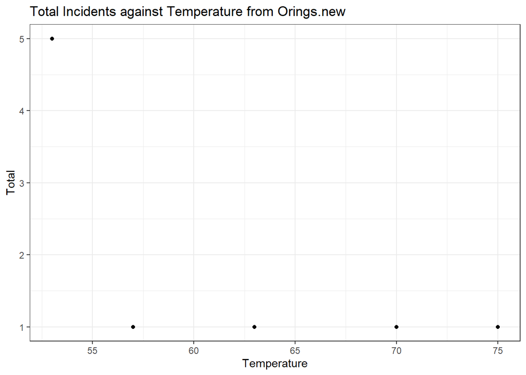

```r
orings.new <- orings[c(1,2,4,11,13,18),]
orings.new %>% ggplot(aes(x=Temperature,y=Total))+
  geom_point()+
  labs(title='Total Incidents against Temperature from Orings.new')+
  theme_bw()
```

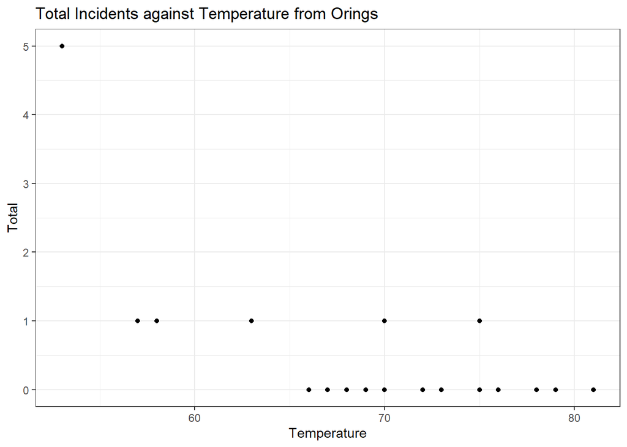

```r
orings %>% ggplot(aes(x=Temperature,y=Total))+
  geom_point()+
  labs(title='Total Incidents against Temperature from Orings')+
  theme_bw()
```

**MB.Ch1.4.** For the data frame `ais` (DAAG package)

1. Use the function `str()` to get information on each of the columns. Determine whether any of the columns hold missing values.

```r
str(ais)
```

```
## 'data.frame':    202 obs. of  13 variables:
##  $ rcc   : num  3.96 4.41 4.14 4.11 4.45 4.1 4.31 4.42 4.3 4.51 ...
##  $ wcc   : num  7.5 8.3 5 5.3 6.8 4.4 5.3 5.7 8.9 4.4 ...
##  $ hc    : num  37.5 38.2 36.4 37.3 41.5 37.4 39.6 39.9 41.1 41.6 ...
##  $ hg    : num  12.3 12.7 11.6 12.6 14 12.5 12.8 13.2 13.5 12.7 ...
##  $ ferr  : num  60 68 21 69 29 42 73 44 41 44 ...
##  $ bmi   : num  20.6 20.7 21.9 21.9 19 ...
##  $ ssf   : num  109.1 102.8 104.6 126.4 80.3 ...
##  $ pcBfat: num  19.8 21.3 19.9 23.7 17.6 ...
##  $ lbm   : num  63.3 58.5 55.4 57.2 53.2 ...
##  $ ht    : num  196 190 178 185 185 ...
##  $ wt    : num  78.9 74.4 69.1 74.9 64.6 63.7 75.2 62.3 66.5 62.9 ...
##  $ sex   : Factor w/ 2 levels "f","m": 1 1 1 1 1 1 1 1 1 1 ...
##  $ sport : Factor w/ 10 levels "B_Ball","Field",..: 1 1 1 1 1 1 1 1 1 1 ...
```

```r
ais_new <- na.omit(ais)
dim(ais)
```

```
## [1] 202  13
```

```r
dim(ais_new)
```

```
## [1] 202  13
```

Explain:Since the ais and ais_new have same dimensions, none of the columns hold missing values.

2. Make a table that shows the numbers of males and females for each different sport. In which sports is there a large imbalance (e.g., by a factor of more than 2:1) in the numbers of the two sexes?

```r
ais_sport <- select(ais,sex=sex,sport=sport)
table(ais_sport)
```

```
##    sport
## sex B_Ball Field Gym Netball Row Swim T_400m T_Sprnt Tennis W_Polo
##   f     13     7   4      23  22    9     11       4      7      0
##   m     12    12   0       0  15   13     18      11      4     17
```

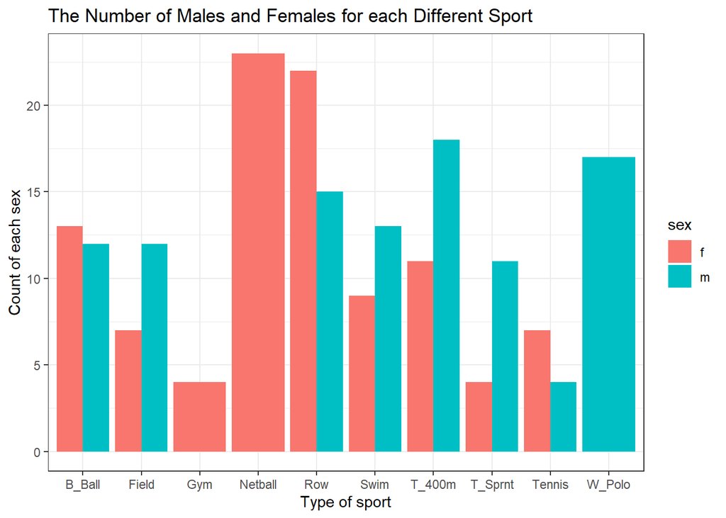

```r
ais %>% ggplot(aes(x=sport,fill=sex))+
  geom_bar(position='dodge')+
  #geom_text(aes(label=count))+
  labs(title='The Number of Males and Females for each Different Sport',x='Type of sport',y='Count of each sex')+
  theme_bw()
```

Explain: By observing the table and figures, we can know that ‘Gym’,‘Netball’,‘T_Sprnt’,‘W_Polo’ have large imbalances in the numbers of the two sexes.

**MB.Ch1.6.** Create a data frame called Manitoba.lakes that contains the lake’s elevation (in meters above sea level) and area (in square kilometers) as listed below. Assign the names of the lakes using the `row.names()` function.

```r
data(Manitoba.lakes)
rownames(Manitoba.lakes) <-rownames(Manitoba.lakes)
Manitoba.lakes
```

```
##                elevation  area
## Winnipeg             217 24387
## Winnipegosis         254  5374
## Manitoba             248  4624
## SouthernIndian       254  2247
## Cedar                253  1353
## Island               227  1223
## Gods                 178  1151
## Cross                207   755
## Playgreen            217   657
```

1. Use the following code to plot `log2(area)` versus elevation, adding labeling information (there is an extreme value of area that makes a logarithmic scale pretty much essential). Devise captions that explain the labeling on the points and on the y-axis. It will be necessary to explain how distances on the scale relate to changes in area.

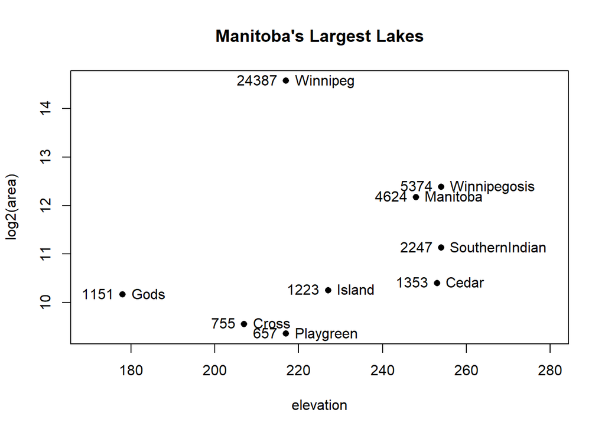

```r
attach(Manitoba.lakes)
plot(log2(area) ~ elevation, pch=16, xlim=c(170,280))
# NB: Doubling the area increases log2(area) by 1.0
text(log2(area) ~ elevation, labels=row.names(Manitoba.lakes), pos=4)
text(log2(area) ~ elevation, labels=area, pos=2)
title("Manitoba's Largest Lakes")
```

Explain: Labels on the points are their true areas, but the labels on the y-axis are the numerical values calculated by the formula $log_2(area)$. Any distance change on the scale needs a exponential change of their true areas.

2. Repeat the plot and associated labeling, now plotting area versus elevation, but specifying `ylog=TRUE` in order to obtain a logarithmic y-scale.

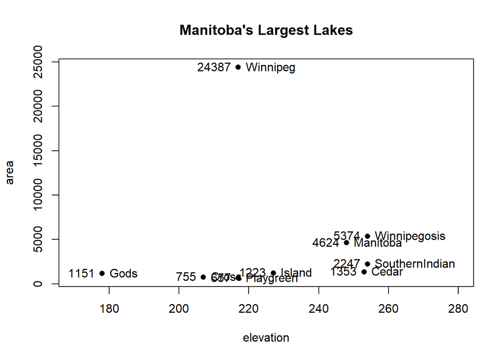

```r
plot(area ~ elevation, pch=16, xlim=c(170,280), ylog=T)
text(area ~ elevation, labels=row.names(Manitoba.lakes), pos=4, ylog=T)
text(area ~ elevation, labels=area, pos=2, ylog=T)
title("Manitoba's Largest Lakes")
```

**MB.Ch1.7.** Look up the help page for the R function `dotchart()`. Use this function to display the areas of the Manitoba lakes (a) on a linear scale, and (b) on a logarithmic scale. Add, in each case, suitable labeling information.

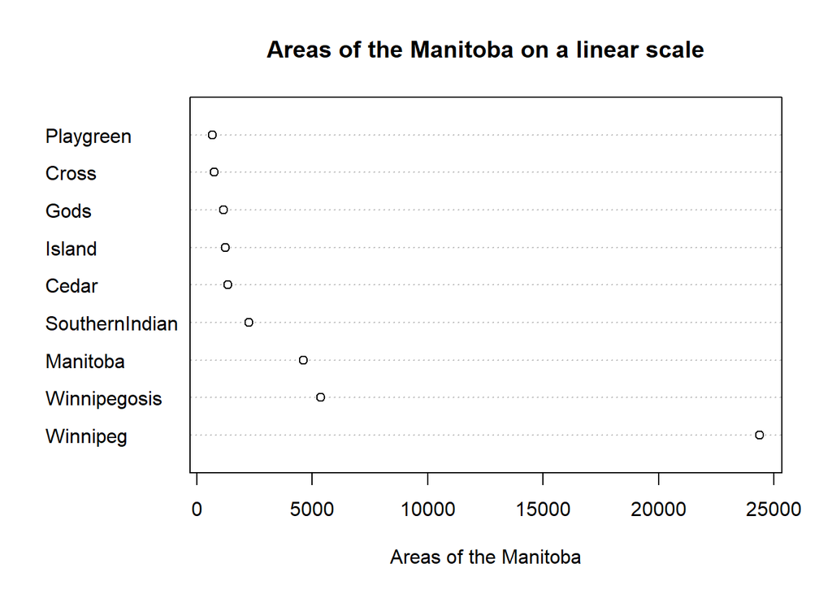

```r
dotchart(area,labels=rownames(Manitoba.lakes),main='Areas of the Manitoba on a linear scale',xlab='Areas of the Manitoba')
```

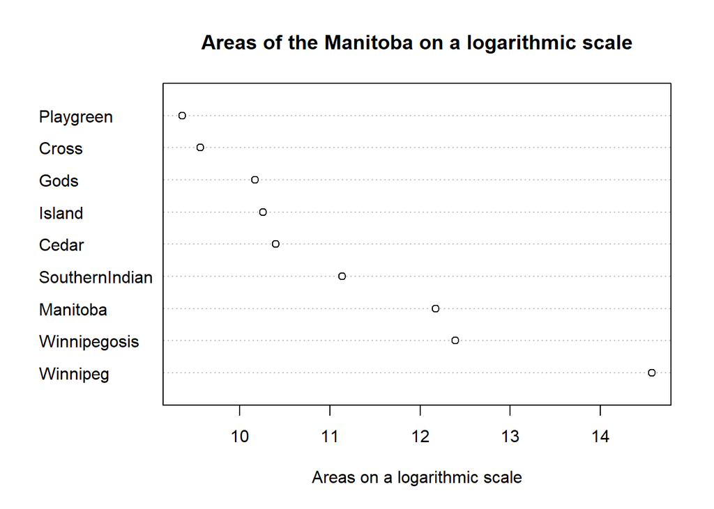

```r
dotchart(log2(area),labels=rownames(Manitoba.lakes), main='Areas of the Manitoba on a logarithmic scale',xlab='Areas on a logarithmic scale')
```

**MB.Ch1.8.** Using the `sum()` function, obtain a lower bound for the area of Manitoba covered by water.

```r
bound <- sum(area)
cat('The lower bound for the area of Manitoba covered by water is',bound)
```

```
## The lower bound for the area of Manitoba covered by water is 41771
```